# individual1

```r
year2020 <- choco[choco$ReviewDate == '2020',]
year2021 <- choco[choco$ReviewDate == '2021',]
length(year2021$Rating)
```

```
## [1] 97
```

```r
hist(year2021$Rating)
summary(year2020$Rating)
```

```
##    Min. 1st Qu.  Median    Mean 3rd Qu.    Max.
##   2.500   3.000   3.250   3.256   3.500   4.000
```

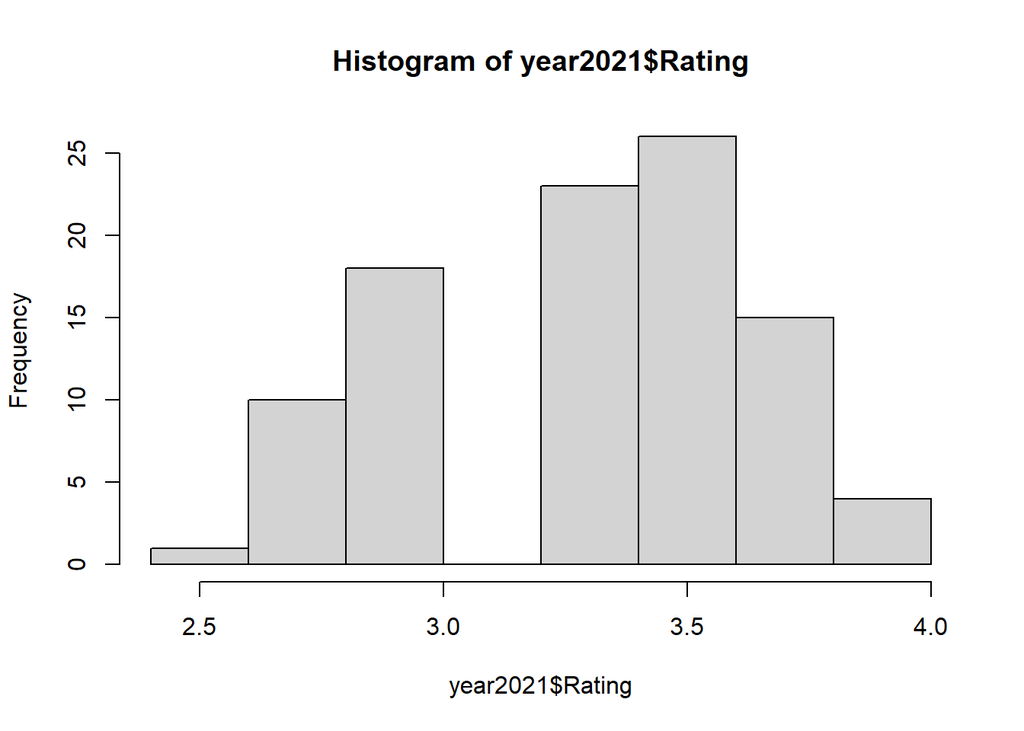

```r
hist(year2021$Rating)
```

```r
summary(year2021$Rating)
```

```
##    Min. 1st Qu.  Median    Mean 3rd Qu.    Max.
##    2.50    3.00    3.25    3.32    3.50    4.00
```

I would also like to preform analysis on the company location and cocoa percentage for the year 2020. First I separate all data from the year 2020. Then I set the names of the company location equal to the cocoa percentage. The I sort the data into the lowest cocoa percentage. I found that the USA had the lowest percentage at 65 cocoa percent. The histogram summary shows the minimum cocoa percentage is 65 and the highest is 75. The mean is 70.74.

```r
dat2020 <- choco[choco$ReviewDate == 2020,]
percentage <- dat2020$CocoaPercent
names(percentage) <- dat2020$Location
sort(percentage)
```

```
##         U.S.A.         U.S.A.         U.S.A.         U.S.A.         U.S.A.
##             65             67             67             67             68
##         U.S.A.         Canada         U.S.A.         U.S.A.         U.S.A.
##             68             68             70             70             70
##         Canada         U.S.A.         U.S.A.         U.S.A.         U.S.A.
##             70             70             70             70             70
##         U.S.A.         U.S.A.         U.S.A.         U.S.A.         U.S.A.
##             70             70             70             70             70
##         Canada         Canada         Canada         Canada         U.S.A.
##             70             70             70             70             70
##         Canada         U.S.A.         Canada         Canada Czech Republic
##             70             70             70             70             70
##         Mexico         U.S.A.         U.S.A.         U.S.A.         U.S.A.
##             70             70             70             70             70
##         U.S.A.         U.S.A.         U.S.A.         U.S.A.         U.S.A.
##             70             70             70             70             70
##         U.S.A.         U.S.A.         U.S.A.         U.S.A.         U.S.A.
##             70             70             70             70             70
##         U.S.A.         U.S.A.         U.S.A.         Canada         Canada
##             70             70             70             70             70
##         U.S.A.         U.S.A.         U.S.A.         Canada         Canada
##             70             70             70             70             70
##         Canada         U.S.A.         U.S.A.         U.S.A.         U.S.A.
##             70             70             72             72             72
##         U.S.A.         U.S.A.         U.S.A.           U.K.         U.S.A.
##             72             72             72             72             72
##         U.S.A.         U.S.A.         U.S.A.         U.S.A.         Canada
##             72             73             73             73             73
##         U.S.A.         U.S.A.         Canada         Canada         U.S.A.
##             73             74             74             74             75
##         U.S.A. Czech Republic         U.S.A.         U.S.A.         U.S.A.
##             75             75             75             75             75
##        Ecuador
##             75
```

```r
lowestpercentage <- head(sort(percentage, decreasing = TRUE))
names(lowestpercentage)
```

```
## [1] "U.S.A."         "U.S.A."         "Czech Republic" "U.S.A."
## [5] "U.S.A."         "U.S.A."
```

```r
rank(percentage)['U.S.A.']
```

```
## U.S.A.
##     73
```

```r
order(percentage)
```

```
##  [1] 42  9 29 39 27 38 69  2  6  8 10 11 12 13 14 15 16 18 20 21 22 23 24 25 28
## [26] 30 40 43 44 45 46 47 48 49 50 51 52 53 54 55 56 57 58 59 60 62 63 64 65 66
## [51] 72 73 74 75 76 77 80  3  4  5 31 32 33 34 35 81 19 36 61 70 79  1 68 78  7
## [76] 17 26 37 41 67 71
```

```r
percentage[42]
```

```
## U.S.A.
##     65
```

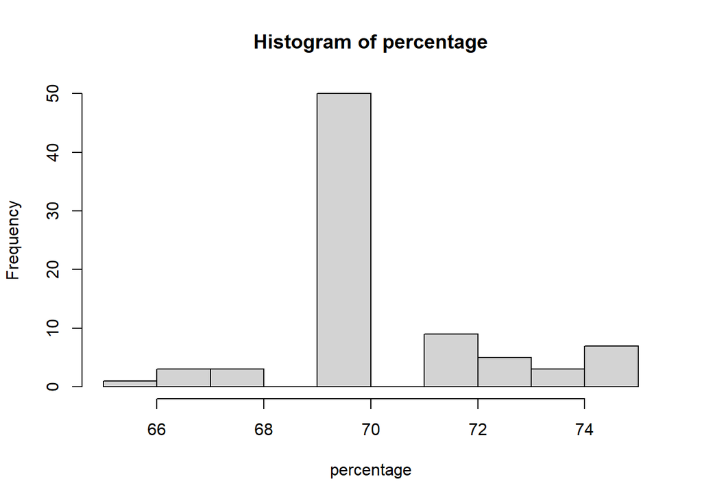

```r
hist(percentage)
```

```r
summary(percentage)
```

```
##    Min. 1st Qu.  Median    Mean 3rd Qu.    Max.
##   65.00   70.00   70.00   70.74   72.00   75.00
```